# Регрессионный анализ

Исаева Анастасия

## 1. Каким образом вы будете оценивать физическую активность респондентов? Есть ли у вас предварительные предположения относительно того, каким образом выбранный вами показатель может быть ассоциирован с гликированным гемоглобином?

Предположительно, низкая физ.активность способствует ожирению, что в свою очередь изменяет гликемию и может привести к изменениям концентрации гликированного гемаглобина в крови. Иными словами, ИМТ (BMI) - медиатор в причинно-следственной связи “Физ.активность –> Грикированный гемоглобин). Чем ниже физ.активность, тем выше риск ожирения, тем выше уровень гликированного гемоглобина (и выше риск развития сахарного диабета).

Физ. активность также может быть ассоциирована с уровнем гликированного гемоглобина напрямую через биохимические пути: сокращение мышц приводит к перемещению белка-переносчика глюкозы (GLUT-4) к плазматической мембране, что способствует увеличению транспорта и метаболизма глюкозы.

По имеющимся данным физ. активность будет оцениваться по переменным Физической активности (начинаутся с “PA…”). Согласно литературе, взрослым рекомендуется заниматься регулярно не менее 150 мин умеренной физ. активностью или 75 мин интенсивной физ.активностью. В датасете имеются данные по физ.активности: - Интенсивная: PAQ605, PAQ610, PAD615, велосипед(PAQ635, PAQ640, PAD645), PAQ650, PAQ655, PAD660  
- Умеренная: PAQ620,PAQ625, PAD630, PAQ665, PAQ670, PAD675 - Сидячая активность: PAD680. Ее в анализе не учитываем, тк она не отображает физическую аквтивность

В дальнейшем мы преобразуем эти переменные в одну “PA”, которая будет взвешенной суммой: Интенсивная физ.активность + Умеренная физ.активность*0,5 (мин/неделя). Коэффициент 0,5 появляется из отношения 75мин/150мин - таким образом умеренная физ активность будет иметь меньший вес чем интенсивная.

## 2.Ковариаты для каких показателей вы включите в модель для коррекции эффекта физической активности в отношении гликированного гемоглобина? Каким образом вы будете их оценивать по имеющимся данным?

*• Бонусное задание: для представленного DAG’а укажите роль каждого показателя по отношению к изучаемой ассоциации между физической активностью и гликированным гемоглобином (конфаундеры (в том числе proxy конфаундеры), коллайдеры, медиаторы)*

Ниже представлен DAG и показатели для коррекции модели.

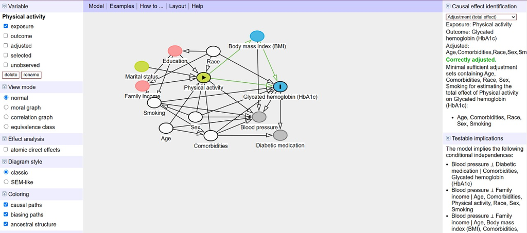

*Примечание*. *При деконфаундинге мы не учитываем BMI, тк он является медиатором в причинно-следственной связи X–>Y. Тк наша задача оценить общий эффект, BMI не учитывается (при оценке прямого эффекта X на Y мы бы учитывали этот медиатор)*

В данной модели учитывается наименьшее необходимое количество переменных для коррекции, чтобы не оверфиттить модель:

-Возраст

-Сопутствующие заболевания

-Раса

-Пол

-Курение

В модели представлены следующие переменные:

1. Конфаундеры (влияют как на зависимую Y, так и на независимую переменную X. Предок X и Предок Y - по пути который не включает X): Раса, Сопутствующие заболевания, Пол
2. Proxy конфаундеры (сами по себе не являются конфаундерами, но лежат между конфаундерами и X или Y): Образование, Курение
3. Коллайдеры (на эти переменные влияют 2 и более переменных. В данном случае ищем коллайдеры по отношению к связи X–>Y): Кровяное давление
4. Медиаторы (переменные на пути связи X–>Y): ИМТ

##3.Проведите необходимый эксплораторный анализ перед оценкой модели.

###Данные

Прочитаем данные и преобразуем некоторые из них в нужный формат. Введем переменную Физ.активности PA (общая физ. активность). Введем категориальную переменную PAC.

PAC= 2 категории: Normal, если общая физ.активность PA ≥ 150 мин/неделя ИЛИ ; Low, если PA ≤ 150 мин/неделя. 150 мин выбрано как бейзлайн, тк PA представляет собой длительность преобразованной в интенсивную физ. активности.

```r
original_data <- readxl::read_xlsx("C:/Users/User/BioStat_2024/GitHub_task/Regression/HW_data.xlsx")
#glimpse(original_data)
#summary(original_data)

mutated_data <- original_data %>%
  mutate(RIAGENDR=as.factor(RIAGENDR),
         RIDRETH3= as.factor(RIDRETH3),
         DMDEDUC2=as.factor(DMDEDUC2),
         DMDMARTL=as.factor(DMDMARTL),
         DMDHHSIZ=as.factor(DMDHHSIZ),
         DMDHHSZA=as.factor(DMDHHSZA),
         DMDHHSZB=as.factor(DMDHHSZB),
         DMDHHSZE=as.factor(DMDHHSZE),
         INDFMIN2=as.factor(INDFMIN2),
         DRQSDIET=as.factor(DRQSDIET),
         DRQSDT1=as.factor(DRQSDT1),
         DRQSDT2=as.factor(DRQSDT2),
         DRQSDT3=as.factor(DRQSDT3),
         DRQSDT4=as.factor(DRQSDT4),
         DRQSDT7=as.factor(DRQSDT7),
         DRQSDT8=as.factor(DRQSDT8),
         DRQSDT9=as.factor(DRQSDT9),
         DRQSDT10=as.factor(DRQSDT10),
         DRQSDT91=as.factor(DRQSDT91),
         DRD340=as.factor(DRD340),
         DRD360=as.factor(DRD360),
         ALQ101=as.factor(ALQ101),
         ALQ120U=as.factor(ALQ120U),
         SMQ020=as.factor(SMQ020),
         SMQ040=as.factor(SMQ040),

         PAQ605=as.factor(PAQ605),
         PAQ620=as.factor(PAQ620),
         PAQ635=as.factor(PAQ635),
         PAQ650=as.factor(PAQ650),

         MCQ010=as.factor(MCQ010),
         MCQ035=as.factor(MCQ035),
         MCQ160C=as.factor(MCQ160C),
         MCQ160B=as.factor(MCQ160B),
         MCQ160E=as.factor(MCQ160E),
         MCQ160F=as.factor(MCQ160F),
         MCQ160M=as.factor(MCQ160M),
         MCQ170M=as.factor(MCQ170M),
         MCQ160O=as.factor(MCQ160O),
         MCQ220=as.factor(MCQ220),
         BPQ020=as.factor(BPQ020),
         BPQ050A=as.factor(BPQ050A),
         DIQ010=as.factor(DIQ010),
         DIQ070=as.factor(DIQ070),
         PA=round((PAQ610*PAD615+PAQ640*PAD645+PAQ655*PAD660+0.5*PAQ625*PAD630+0.5*PAQ670*PAD675)/7,2) #формула для PA
) %>%
  mutate(PAC=ifelse(PA==150|PA>150, "Normal", "Low")) %>%
  mutate(PAC=as.factor(PAC))
#glimpse(mutated_data)
#summary(mutated_data)
mutated_data %>% head()
```

```
## # A tibble: 6 × 76
##    SEQN DMDEDUC2 DMDHHSIZ DMDHHSZA DMDHHSZB DMDHHSZE DMDMARTL INDFMIN2 RIAGENDR
##   <dbl> <fct>    <fct>    <fct>    <fct>    <fct>    <fct>    <fct>    <fct>
## 1 81603 4        1        0        0        1        2        4        2
## 2 81783 5        3        0        1        0        1        12       1
## 3 80825 3        5        0        2        0        1        7        1
## 4 74081 4        2        0        0        2        1        5        1
## 5 83352 3        6        0        1        1        5        12       1
## 6 79661 3        7        1        2        0        1        12       1
## # ℹ 67 more variables: RIDAGEYR <dbl>, RIDRETH3 <fct>, DR1TALCO <dbl>,
## #   DR1TCHOL <dbl>, DR1TFIBE <dbl>, DR1TKCAL <dbl>, DR1TMFAT <dbl>,
## #   DR1TPFAT <dbl>, DR1TSFAT <dbl>, DR1TSUGR <dbl>, DR1TTFAT <dbl>,
## #   DRD340 <fct>, DRD360 <fct>, DRQSDIET <fct>, DRQSDT1 <fct>, DRQSDT10 <fct>,
## #   DRQSDT2 <fct>, DRQSDT3 <fct>, DRQSDT4 <fct>, DRQSDT7 <fct>, DRQSDT8 <fct>,
## #   DRQSDT9 <fct>, DRQSDT91 <fct>, BMXBMI <dbl>, BMXHT <dbl>, BMXWT <dbl>,
## #   LBXGH <dbl>, BPQ020 <fct>, BPQ050A <fct>, MCQ010 <fct>, MCQ035 <fct>, …
```

### Описательные статистики

Для нашей модели интересны следующие данные:

Воздействие: Физ. активность (PA ИЛИ PAC)

Исход: Гликированный гемаглобин (LBXGH)

Конфаундеры: Возраст (RIDAGEYR), Сопутствующие заболевания (Учитываются заболевания на протяжении жизни: MCQ010-asthma, MCQ160C-coronary heart disease, MCQ160B-congestive heart failure, MCQ160E-heart attack, MCQ160F-stroke, MCQ160M-thyroid problem, MCQ160O-COPD, MCQ220-malignancy, BPQ020-high blood pressure), Раса (RIDRETH3), Пол (RIAGENDR), Курение (SMQ040. Показатель SMQ020 не показателен, если респондент бросил курить)

В некоторых категориальных переменных есть ошибки. Выбросим строки, содержащие их (NA)

```r
mutated_data_var<-mutated_data %>% select(PA, PAC, LBXGH, RIDAGEYR, MCQ010, MCQ160C, MCQ160B, MCQ160E, MCQ160F, MCQ160M, MCQ160O, MCQ220, BPQ020, RIDRETH3, RIAGENDR, SMQ040) %>%
  rename_with(function(x) x %>%
              str_replace("PAC","Physical activity category") %>%
              str_replace("PA","Physical activity") %>%
              str_replace("LBXGH","Glycohemoglobin (%)") %>%
              str_replace("RIDAGEYR","Age")%>%
              str_replace("MCQ010","asthma")%>%
              str_replace("MCQ160C","coronary heart disease")%>%
              str_replace("MCQ160B","congestive heart failure")%>%
              str_replace("MCQ160E","heart attack")%>%
              str_replace("MCQ160F","stroke")%>%
              str_replace("MCQ160M","thyroid problem")%>%
              str_replace("MCQ160O","COPD")%>%
              str_replace("MCQ220","malignancy")%>%
              str_replace("BPQ020","high blood pressure")%>%
              str_replace("RIDRETH3","Race")%>%
              str_replace("SMQ040","Smoking") %>%
              str_replace("RIAGENDR","Sex")) %>%
   mutate(across(Sex, function(x) x %>%
                  factor(levels=c("1","2"), labels=c("Male", "Female")))) %>%
  mutate(across(asthma, function(x) x %>%
                  factor(levels=c("1","2"), labels=c("Yes", "No")))) %>%
  mutate(across('coronary heart disease', function(x) x %>%
                  factor(levels=c("1","2"), labels=c("Yes", "No")))) %>%
  mutate(across('congestive heart failure', function(x) x %>%
                  factor(levels=c("1","2"), labels=c("Yes", "No")))) %>%
  mutate(across('heart attack', function(x) x %>%
                  factor(levels=c("1","2"), labels=c("Yes", "No")))) %>%
  mutate(across('stroke', function(x) x %>%
                  factor(levels=c("1","2"), labels=c("Yes", "No")))) %>%
  mutate(across('thyroid problem', function(x) x %>%
                  factor(levels=c("1","2"), labels=c("Yes", "No")))) %>%
  mutate(across('COPD', function(x) x %>%
                  factor(levels=c("1","2"), labels=c("Yes", "No")))) %>%
  mutate(across('malignancy', function(x) x %>%
                  factor(levels=c("1","2"), labels=c("Yes", "No")))) %>%
  mutate(across('high blood pressure', function(x) x %>%
                  factor(levels=c("1","2"), labels=c("Yes", "No")))) %>%
   mutate(across('Race', function(x) x %>%
                  factor(levels=c("1","2","3","4", "6","7"), labels=c("Mexican American", "Other Hispanic", "Non-Hispanic White", "Non-Hispanic Black", "Non-Hispanic Asian", "Other Race - Including Multi-Racial")))) %>%
    mutate(across('Smoking', function(x) x %>%
                  factor(levels=c("1","2","3"), labels=c("Every day", "Some days", "Not at all")))) %>%
    drop_na()

tbl_summary(
  mutated_data_var,
  type = list(all_continuous() ~ "continuous2"),
  statistic = list(
    all_continuous() ~ c("{mean} ({sd})", "{median} ({p25}-{p75})", "{min}-{max}")
  )) %>%
  modify_footnote(everything() ~ NA) %>%
  bold_labels()
```

| **Characteristic** | **N = 913** |
| --- | --- |
| Physical activity |  |
| Mean (SD) | 59 (94) |
| Median (Q1-Q3) | 20 (0-69) |
| Min-Max | 0-643 |
| Physical activity category |  |
| Low | 796 (87%) |
| Normal | 117 (13%) |
| Glycohemoglobin (%) |  |
| Mean (SD) | 5.80 (1.04) |
| Median (Q1-Q3) | 5.60 (5.30-5.90) |
| Min-Max | 4.20-13.90 |
| Age |  |
| Mean (SD) | 55 (16) |
| Median (Q1-Q3) | 56 (45-67) |
| Min-Max | 20-80 |
| asthma | 144 (16%) |
| coronary heart disease | 44 (4.8%) |
| congestive heart failure | 34 (3.7%) |
| heart attack | 41 (4.5%) |
| stroke | 32 (3.5%) |
| thyroid problem | 127 (14%) |
| COPD | 38 (4.2%) |
| malignancy | 103 (11%) |
| high blood pressure | 407 (45%) |
| Race |  |
| Mexican American | 101 (11%) |
| Other Hispanic | 75 (8.2%) |
| Non-Hispanic White | 461 (50%) |
| Non-Hispanic Black | 174 (19%) |
| Non-Hispanic Asian | 78 (8.5%) |
| Other Race - Including Multi-Racial | 24 (2.6%) |
| Sex |  |
| Male | 538 (59%) |
| Female | 375 (41%) |
| Smoking |  |
| Every day | 133 (15%) |
| Some days | 31 (3.4%) |
| Not at all | 749 (82%) |

```r
#summary(mutated_data_var)
```

####Графики Объединим все сопутствующие заболевания в одну переменную, которая покажет наличие или отсутствие таких заболеваний (asthma, `coronary heart disease`, `congestive heart failure`, `heart attack`, `stroke`,`thyroid problem`, COPD, malignancy, `high blood pressure`). Данное преобразование делаем для упрощения последующего графика.

```r
mutated_data_var_com<-mutated_data_var %>%
  mutate(comorbidities=ifelse(asthma=="yes"| `coronary heart disease`=="yes"| `congestive heart failure`=="yes"| `heart attack`=="yes"| stroke=="yes"| `thyroid problem`=="yes"| COPD=="yes"| malignancy=="yes"| `high blood pressure`=="Yes","Yes","No")) %>%
  mutate(comorbidities=as.factor(comorbidities))

#summary(mutated_data_var_com)
```

Построим общий описательный график

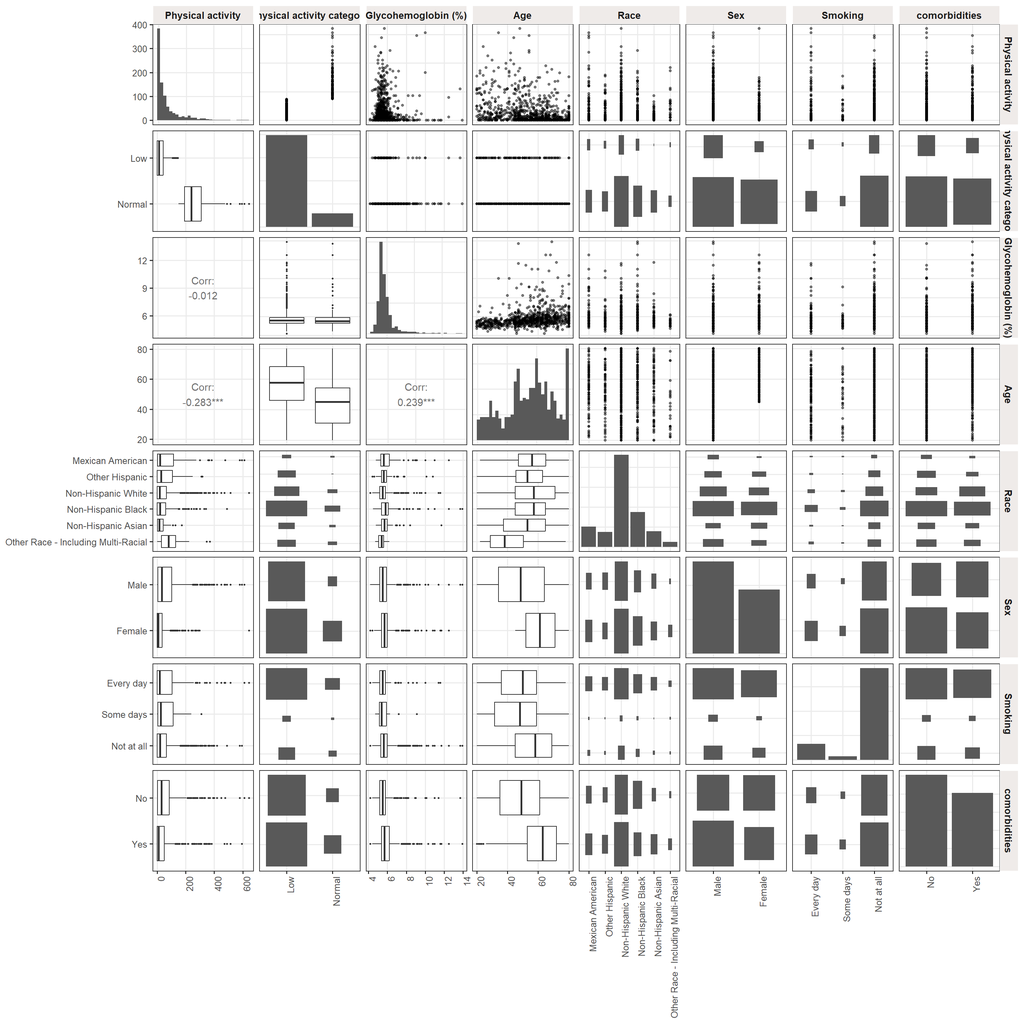

```r
ggpairs(
  mutated_data_var_com %>% dplyr::select(`Physical activity`, `Physical activity category`, `Glycohemoglobin (%)`, Age, Race, Sex, Smoking, comorbidities ),
  upper = list(continuous = wrap("points", alpha = 0.5, size = 1),
               combo = wrap("points", alpha = 0.5, size = 1),
               disrete = "blank"),
  lower = list(continuous = "cor",
               discrete = "count",
               combo = wrap("box_no_facet", outlier.size = 0.5)),
  diag = list(continuous = "barDiag",
              discrete = "barDiag"),
  showStrips = TRUE, progress = FALSE) +
  theme_bw(base_size = 12) +
  theme(axis.text.x = element_text(angle = 90, hjust = 1),
        panel.grid.minor = element_blank(),
        strip.placement = "outside",
        strip.background = element_rect(color = "white", fill = "#EFEBE9"),
        strip.text = element_text(size = 10, face = "bold"))
```

По графикам видно, что распределение Физ.активности и гликированного гемоглобина скошено в область низких значений. Статистически значимой корреляции между Физ. активностью и гликированным гемоглобином нет, значит можно предположить отсутствие линейной зависимости. Следовательно, либо зависимость нелинейна, либо ковариаты искажают зависимость, либо зависимости нет вовсе (вариант с малым количеством наблюдений в выборке исключаем). Оценивать данную зависимость будем линейной регрессией. В целом, можно разделить Физ. активность на группы (нормальная/ниже нормы), но при переводе количественной переменной в категориальную теряется информация. Есть статистически значимые корреляции между Физ.активностью и возрастом (отрицательная), а также между уровнем Гликированного гемоглобина и возрастом. Возможно, в дальнейшем придется исключить Age из модели (заменить ее другими конфаундерами) - это покажет анализ VIF.

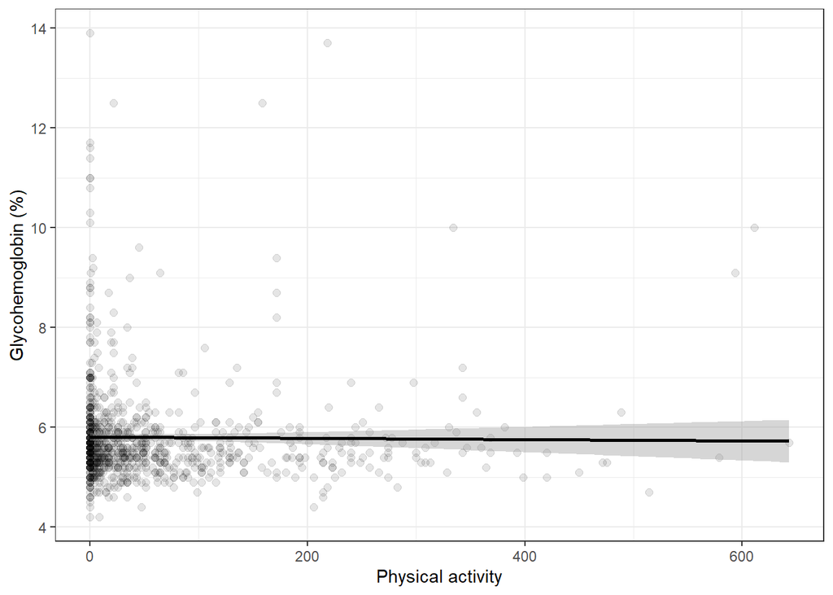

```r
ggplot(mutated_data_var_com, aes(x=`Physical activity`, y=`Glycohemoglobin (%)`)) +
     geom_point(size = 2, alpha=0.1) +
     theme_bw() +
     geom_smooth(method = "lm", formula = y ~ x, se = T,
                 colour = 'black',size=1)
```

## 4. Оцените модель для зависимости гликированного гемоглобина от выбранного вами показателя физической активности без ковариат и с ними. Проведите необходимую диагностику этих моделей – требует ли что-либо коррекции и почему? В случае необходимости коррекции по результатам диагностики сделайте ее.

Модель зависисмости Уровня Гликированного гемоглобина от времени Физ. активности в неделю без ковариат:

```r
mutated_data_var_fit <- lm(`Glycohemoglobin (%)` ~ `Physical activity`, mutated_data_var)
#print(mutated_data_var_fit)
#summary(mutated_data_var_fit)
broom::tidy(mutated_data_var_fit, conf.int = TRUE)
```

```
## # A tibble: 2 × 7
##   term                 estimate std.error statistic p.value  conf.low conf.high
##   <chr>                   <dbl>     <dbl>     <dbl>   <dbl>     <dbl>     <dbl>
## 1 (Intercept)          5.81      0.0405     143.      0      5.73      5.89
## 2 `Physical activity` -0.000130  0.000365    -0.356   0.722 -0.000846  0.000586
```

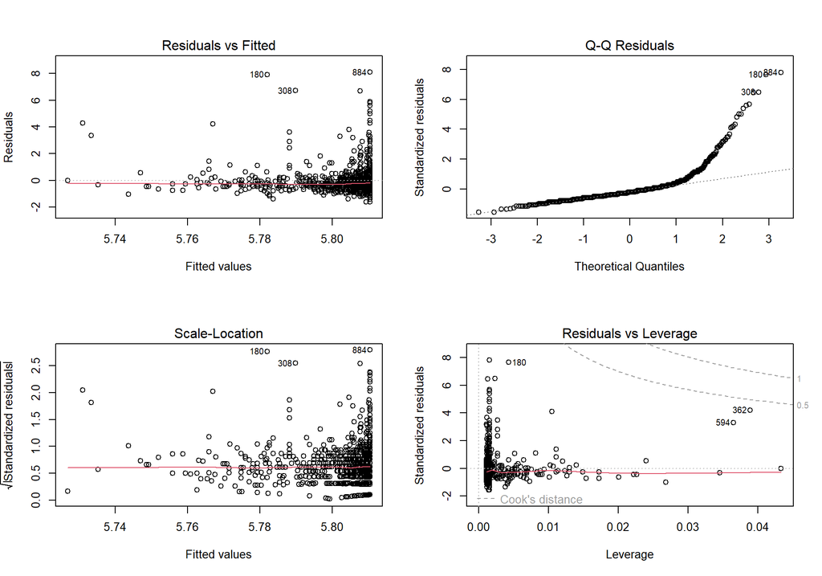

```r
par(mfrow = c(2, 2))
plot(mutated_data_var_fit)
```

```r
#autoplot(mutated_data_var_fit)
#2*(1+1)/913
```

Модель с ковариатами (возрастом, расой, полом, курением и сопутствующими заболеваниями):

```r
mutated_data_var_cov_fit <- lm(`Glycohemoglobin (%)` ~ `Physical activity` + Age + Race + Sex + Smoking + asthma + `coronary heart disease`+ `congestive heart failure`+ `heart attack`+ `stroke`+`thyroid problem`+ COPD + malignancy + `high blood pressure`, mutated_data_var)
#print(mutated_data_var_cov_fit)
#summary(mutated_data_var_cov_fit)
broom::tidy(mutated_data_var_cov_fit, conf.int = TRUE)
```

```
## # A tibble: 20 × 7
##    term                 estimate std.error statistic  p.value conf.low conf.high
##    <chr>                   <dbl>     <dbl>     <dbl>    <dbl>    <dbl>     <dbl>
##  1 (Intercept)           6.73e+0  0.378       17.8   8.54e-61  5.99e+0  7.47
##  2 `Physical activity`   6.24e-4  0.000368     1.70  9.03e- 2 -9.83e-5  0.00135
##  3 Age                   1.26e-2  0.00252      5.01  6.55e- 7  7.69e-3  0.0176
##  4 RaceOther Hispanic   -2.68e-1  0.150       -1.79  7.44e- 2 -5.63e-1  0.0265
##  5 RaceNon-Hispanic Wh… -4.55e-1  0.109       -4.18  3.23e- 5 -6.68e-1 -0.241
##  6 RaceNon-Hispanic Bl… -2.44e-2  0.124       -0.196 8.45e- 1 -2.68e-1  0.219
##  7 RaceNon-Hispanic As… -1.08e-1  0.150       -0.725 4.69e- 1 -4.02e-1  0.185
##  8 RaceOther Race - In… -4.40e-1  0.225       -1.96  5.05e- 2 -8.81e-1  0.000941
##  9 SexFemale             1.97e-2  0.0745       0.264 7.92e- 1 -1.27e-1  0.166
## 10 SmokingSome days     -9.67e-2  0.196       -0.494 6.22e- 1 -4.81e-1  0.288
## 11 SmokingNot at all    -5.39e-2  0.0953      -0.565 5.72e- 1 -2.41e-1  0.133
## 12 asthmaNo             -1.56e-2  0.0910      -0.172 8.64e- 1 -1.94e-1  0.163
## 13 `coronary heart dis… -4.74e-1  0.185       -2.57  1.05e- 2 -8.36e-1 -0.111
## 14 `congestive heart f… -2.89e-1  0.198       -1.46  1.44e- 1 -6.77e-1  0.0989
## 15 `heart attack`No     -2.20e-1  0.188       -1.17  2.42e- 1 -5.88e-1  0.148
## 16 strokeNo             -4.57e-1  0.179       -2.55  1.10e- 2 -8.10e-1 -0.105
## 17 `thyroid problem`No   5.99e-2  0.100        0.596 5.51e- 1 -1.37e-1  0.257
## 18 COPDNo                1.61e-1  0.174        0.924 3.56e- 1 -1.80e-1  0.502
## 19 malignancyNo         -9.13e-2  0.109       -0.836 4.03e- 1 -3.06e-1  0.123
## 20 `high blood pressur… -1.24e-1  0.0725      -1.71  8.75e- 2 -2.66e-1  0.0183
```

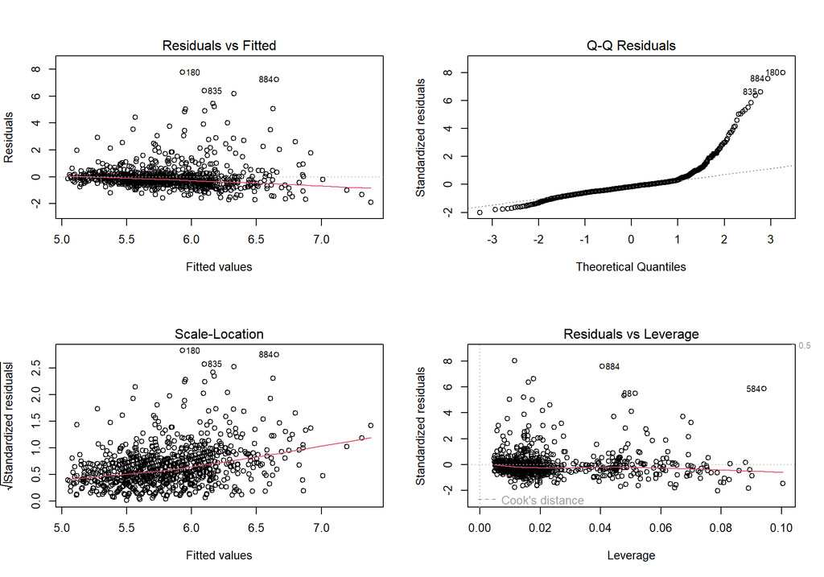

```r
#autoplot(mutated_data_var_cov_fit)
par(mfrow = c(2, 2))
plot(mutated_data_var_cov_fit)
```

```r
#2*(1+1)/913
```

Расстояние Кука:

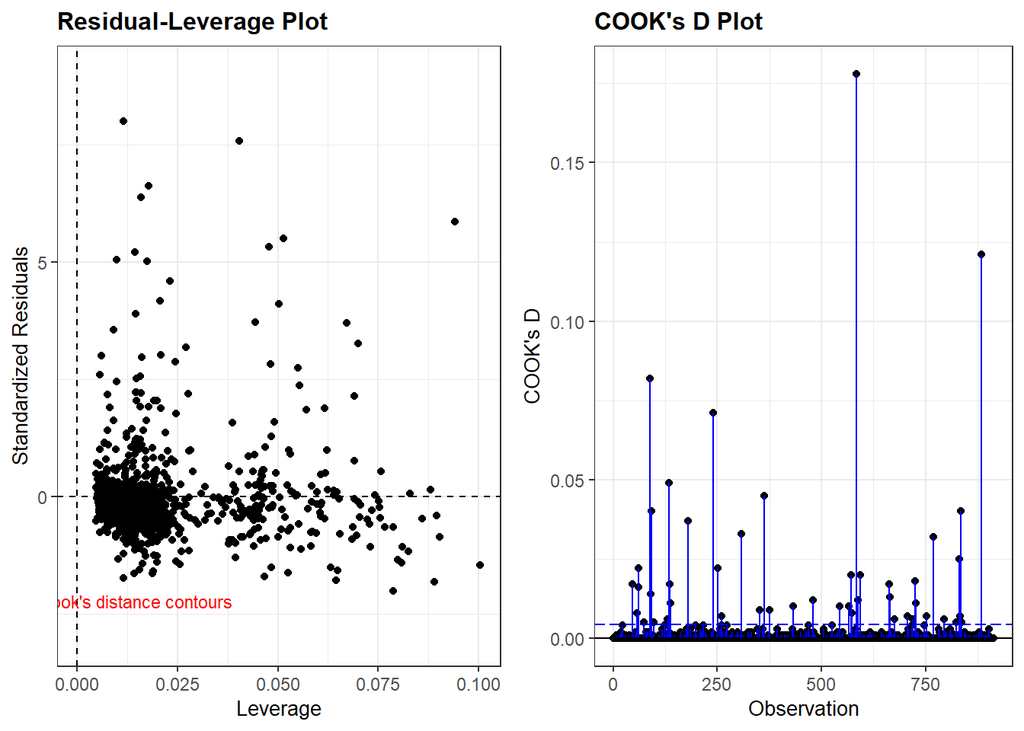

```r
resid_panel(mutated_data_var_cov_fit, plots = c("lev", "cookd"))
```

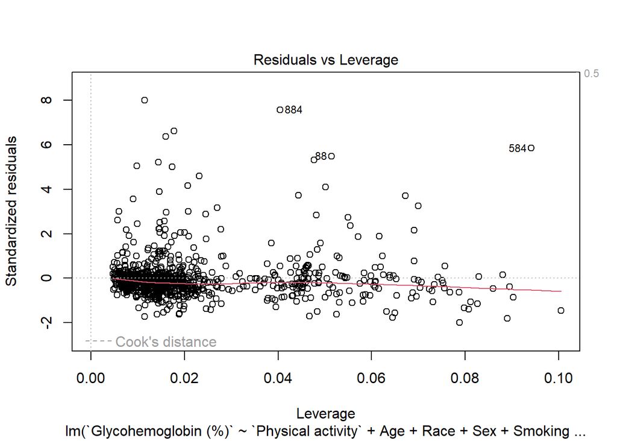

```r
plot(mutated_data_var_cov_fit, 5)
```

Проверка на мультиколинеарность:

Коэффициенты корреляции Пирсона:

```r
cor(mutated_data_var %>% dplyr::select(`Physical activity`, Age))
```

```
##                   Physical activity        Age
## Physical activity         1.0000000 -0.2827903
## Age                      -0.2827903  1.0000000
```

VIF не высокий, мультиколинеарность отсутствует

```r
car::vif(lm(`Glycohemoglobin (%)` ~ `Physical activity` + Age, mutated_data_var))
```

```
## `Physical activity`                 Age
##            1.086921            1.086921
```

## 5. Представьте результаты оценки модели без ковариат и с ковариатами в виде точечной и интервальной оценки эффекта физической активности. Дайте им словесную интерпретацию. Какие выводы мы можем сделать, исходя из точечной оценки? А из интервальной? Как вы думаете, можно ли считать эффект клинически значимым? Если затрудняетесь с ответом, что бы вам помогло дать ответ на этот вопрос?

Точечная оценка эффекта воздействия на исход - константа регрессии и коэффициент регрессии при воздействии. Интервальная заключается в ДИ точечных оценок.

Модель без ковариат (без и с коррекцией на гетероскедастичность):

```r
broom::tidy(mutated_data_var_fit, conf.int = TRUE)
```

```
## # A tibble: 2 × 7
##   term                 estimate std.error statistic p.value  conf.low conf.high
##   <chr>                   <dbl>     <dbl>     <dbl>   <dbl>     <dbl>     <dbl>
## 1 (Intercept)          5.81      0.0405     143.      0      5.73      5.89
## 2 `Physical activity` -0.000130  0.000365    -0.356   0.722 -0.000846  0.000586
```

```r
broom::tidy(coeftest(mutated_data_var_fit, vcov. = vcovHC, type = "HC4"), conf.int = TRUE)
```

```
## # A tibble: 2 × 7
##   term                 estimate std.error statistic p.value conf.low conf.high
##   <chr>                   <dbl>     <dbl>     <dbl>   <dbl>    <dbl>     <dbl>
## 1 (Intercept)          5.81      0.0438     133.      0      5.72     5.90
## 2 `Physical activity` -0.000130  0.000524    -0.248   0.804 -0.00116  0.000898
```

Модель с ковариатами (без и с коррекцией на гетероскедастичность):

```r
broom::tidy(mutated_data_var_cov_fit, conf.int = TRUE)
```

```
## # A tibble: 20 × 7
##    term                 estimate std.error statistic  p.value conf.low conf.high
##    <chr>                   <dbl>     <dbl>     <dbl>    <dbl>    <dbl>     <dbl>
##  1 (Intercept)           6.73e+0  0.378       17.8   8.54e-61  5.99e+0  7.47
##  2 `Physical activity`   6.24e-4  0.000368     1.70  9.03e- 2 -9.83e-5  0.00135
##  3 Age                   1.26e-2  0.00252      5.01  6.55e- 7  7.69e-3  0.0176
##  4 RaceOther Hispanic   -2.68e-1  0.150       -1.79  7.44e- 2 -5.63e-1  0.0265
##  5 RaceNon-Hispanic Wh… -4.55e-1  0.109       -4.18  3.23e- 5 -6.68e-1 -0.241
##  6 RaceNon-Hispanic Bl… -2.44e-2  0.124       -0.196 8.45e- 1 -2.68e-1  0.219
##  7 RaceNon-Hispanic As… -1.08e-1  0.150       -0.725 4.69e- 1 -4.02e-1  0.185
##  8 RaceOther Race - In… -4.40e-1  0.225       -1.96  5.05e- 2 -8.81e-1  0.000941
##  9 SexFemale             1.97e-2  0.0745       0.264 7.92e- 1 -1.27e-1  0.166
## 10 SmokingSome days     -9.67e-2  0.196       -0.494 6.22e- 1 -4.81e-1  0.288
## 11 SmokingNot at all    -5.39e-2  0.0953      -0.565 5.72e- 1 -2.41e-1  0.133
## 12 asthmaNo             -1.56e-2  0.0910      -0.172 8.64e- 1 -1.94e-1  0.163
## 13 `coronary heart dis… -4.74e-1  0.185       -2.57  1.05e- 2 -8.36e-1 -0.111
## 14 `congestive heart f… -2.89e-1  0.198       -1.46  1.44e- 1 -6.77e-1  0.0989
## 15 `heart attack`No     -2.20e-1  0.188       -1.17  2.42e- 1 -5.88e-1  0.148
## 16 strokeNo             -4.57e-1  0.179       -2.55  1.10e- 2 -8.10e-1 -0.105
## 17 `thyroid problem`No   5.99e-2  0.100        0.596 5.51e- 1 -1.37e-1  0.257
## 18 COPDNo                1.61e-1  0.174        0.924 3.56e- 1 -1.80e-1  0.502
## 19 malignancyNo         -9.13e-2  0.109       -0.836 4.03e- 1 -3.06e-1  0.123
## 20 `high blood pressur… -1.24e-1  0.0725      -1.71  8.75e- 2 -2.66e-1  0.0183
```

```r
broom::tidy(coeftest(mutated_data_var_cov_fit, vcov. = vcovHC, type = "HC4"), conf.int = TRUE)
```

```
## # A tibble: 20 × 7
##    term                 estimate std.error statistic  p.value conf.low conf.high
##    <chr>                   <dbl>     <dbl>     <dbl>    <dbl>    <dbl>     <dbl>
##  1 (Intercept)           6.73e+0  0.614       11.0   2.64e-26  5.52e+0   7.93
##  2 `Physical activity`   6.24e-4  0.000499     1.25  2.11e- 1 -3.54e-4   0.00160
##  3 Age                   1.26e-2  0.00209      6.06  1.98e- 9  8.55e-3   0.0167
##  4 RaceOther Hispanic   -2.68e-1  0.165       -1.63  1.04e- 1 -5.91e-1   0.0552
##  5 RaceNon-Hispanic Wh… -4.55e-1  0.131       -3.48  5.32e- 4 -7.11e-1  -0.198
##  6 RaceNon-Hispanic Bl… -2.44e-2  0.163       -0.150 8.81e- 1 -3.43e-1   0.295
##  7 RaceNon-Hispanic As… -1.08e-1  0.157       -0.690 4.91e- 1 -4.17e-1   0.200
##  8 RaceOther Race - In… -4.40e-1  0.150       -2.93  3.43e- 3 -7.34e-1  -0.146
##  9 SexFemale             1.97e-2  0.0827       0.238 8.12e- 1 -1.43e-1   0.182
## 10 SmokingSome days     -9.67e-2  0.182       -0.530 5.96e- 1 -4.54e-1   0.261
## 11 SmokingNot at all    -5.39e-2  0.100       -0.537 5.92e- 1 -2.51e-1   0.143
## 12 asthmaNo             -1.56e-2  0.0902      -0.173 8.63e- 1 -1.93e-1   0.161
## 13 `coronary heart dis… -4.74e-1  0.246       -1.93  5.45e- 2 -9.57e-1   0.00922
## 14 `congestive heart f… -2.89e-1  0.340       -0.850 3.96e- 1 -9.57e-1   0.379
## 15 `heart attack`No     -2.20e-1  0.246       -0.894 3.71e- 1 -7.02e-1   0.263
## 16 strokeNo             -4.57e-1  0.391       -1.17  2.42e- 1 -1.22e+0   0.309
## 17 `thyroid problem`No   5.99e-2  0.115        0.519 6.04e- 1 -1.67e-1   0.287
## 18 COPDNo                1.61e-1  0.221        0.726 4.68e- 1 -2.73e-1   0.595
## 19 malignancyNo         -9.13e-2  0.113       -0.807 4.20e- 1 -3.13e-1   0.131
## 20 `high blood pressur… -1.24e-1  0.0714      -1.74  8.24e- 2 -2.64e-1   0.0160
```

Константа регрессии: При отсутствии Физической активности (0 мин в неделю) у респондентов базово уровень гликированного гемоглобина = 6.7% Коэффициент регрессии: При изменении длительности Физ. активности на 1 мин в неделю и равенстве остальных ковариат статистически значимого изменения уровня гликированного гемоглобина нет (ДИ включает 0, p значение больше 0,05)

Клинически значимого эффекта от увеличения длительности физ.активности на 1 мин в неделю при прочих равных условиях на уровень гликированного гемоглобина нет

Интересно, что и при разделении физ. активности на категории в соответствии с нормой из литературы, статистически значимой зависимости уровня гликированного гемоглобина от категории физ. активности (нома или ниже нормы) нет (модель коррекцией на гетероскедастичность, тк она наблюдается в такой модели тоже):

```r
mutated_data_var_cov_fit2 <- lm(`Glycohemoglobin (%)` ~ `Physical activity category` + Age + Race + Sex + Smoking + asthma + `coronary heart disease`+ `congestive heart failure`+ `heart attack`+ `stroke`+`thyroid problem`+ COPD + malignancy + `high blood pressure`, mutated_data_var)


broom::tidy(coeftest(mutated_data_var_cov_fit2, vcov. = vcovHC, type = "HC4"), conf.int = TRUE)
```

```
## # A tibble: 20 × 7
##    term                 estimate std.error statistic  p.value conf.low conf.high
##    <chr>                   <dbl>     <dbl>     <dbl>    <dbl>    <dbl>     <dbl>
##  1 (Intercept)            6.71     0.611      11.0   2.21e-26  5.51       7.91
##  2 `Physical activity …   0.245    0.129       1.90  5.79e- 2 -0.00820    0.499
##  3 Age                    0.0129   0.00211     6.10  1.54e- 9  0.00872    0.0170
##  4 RaceOther Hispanic    -0.265    0.165      -1.61  1.08e- 1 -0.589      0.0579
##  5 RaceNon-Hispanic Wh…  -0.456    0.131      -3.48  5.22e- 4 -0.713     -0.199
##  6 RaceNon-Hispanic Bl…  -0.0275   0.163      -0.169 8.66e- 1 -0.348      0.293
##  7 RaceNon-Hispanic As…  -0.0980   0.157      -0.623 5.33e- 1 -0.407      0.211
##  8 RaceOther Race - In…  -0.420    0.148      -2.85  4.54e- 3 -0.710     -0.130
##  9 SexFemale              0.0190   0.0828      0.230 8.18e- 1 -0.144      0.182
## 10 SmokingSome days      -0.0922   0.183      -0.505 6.14e- 1 -0.451      0.266
## 11 SmokingNot at all     -0.0570   0.101      -0.565 5.72e- 1 -0.255      0.141
## 12 asthmaNo              -0.0128   0.0901     -0.142 8.87e- 1 -0.190      0.164
## 13 `coronary heart dis…  -0.467    0.246      -1.90  5.83e- 2 -0.950      0.0164
## 14 `congestive heart f…  -0.282    0.341      -0.829 4.07e- 1 -0.951      0.386
## 15 `heart attack`No      -0.212    0.246      -0.865 3.87e- 1 -0.694      0.270
## 16 strokeNo              -0.456    0.389      -1.17  2.41e- 1 -1.22       0.307
## 17 `thyroid problem`No    0.0564   0.115       0.490 6.24e- 1 -0.169      0.282
## 18 COPDNo                 0.155    0.221       0.700 4.84e- 1 -0.279      0.588
## 19 malignancyNo          -0.0917   0.113      -0.811 4.18e- 1 -0.314      0.130
## 20 `high blood pressur…  -0.125    0.0710     -1.76  7.88e- 2 -0.264      0.0144
```

## 6. Проверьте гипотезу об отсутствии ассоциации между физической активностью и гликированным гемоглобином. Сделайте выводы по полученным результатам.*** Берем модель с ковариатами и оцениваем гипотезу о равенстве 0 коэффициента регрессии у Физ. активности (с поправкой на гетероскедастичность):

```r
car::linearHypothesis(mutated_data_var_cov_fit, names(coef(mutated_data_var_cov_fit)[2]),  vcov. = vcovHC, type = "HC4")
```

```
## Linear hypothesis test
##
## Hypothesis:
## Physical activity` = 0
##
## Model 1: restricted model
## Model 2: `Glycohemoglobin (%)` ~ `Physical activity` + Age + Race + Sex +
##     Smoking + asthma + `coronary heart disease` + `congestive heart failure` +
##     `heart attack` + stroke + `thyroid problem` + COPD + malignancy +
##     `high blood pressure`
##
## Note: Coefficient covariance matrix supplied.
##
##   Res.Df Df      F Pr(>F)
## 1    894
## 2    893  1 1.5742 0.2099
```

Таким образом, при уровне значимости 0.05 гипотезу об отсутствии ассоциации между физической активностью и гликированным гемоглобином не отвергается. Даже при учете ковариат мы не можем сделать вывод о зависимости уровня гликированного гемоглобина от длительности физ.активности

Также мы не можем отвергнуть гипотезу о том, что ассоциация гликированного гемоглобина с категорией физ.активности (норма/ниже нормы) отсутствует:

```r
car::linearHypothesis(mutated_data_var_cov_fit2, names(coef(mutated_data_var_cov_fit2)[2]),  vcov. = vcovHC, type = "HC4")
```

[output not shown]

### 7. Является ли пол модификатором эффекта физической активности в отношении гликированного гемоглобина? Если да, каков эффект для мужчин и женщин и насколько он отличается между ними?

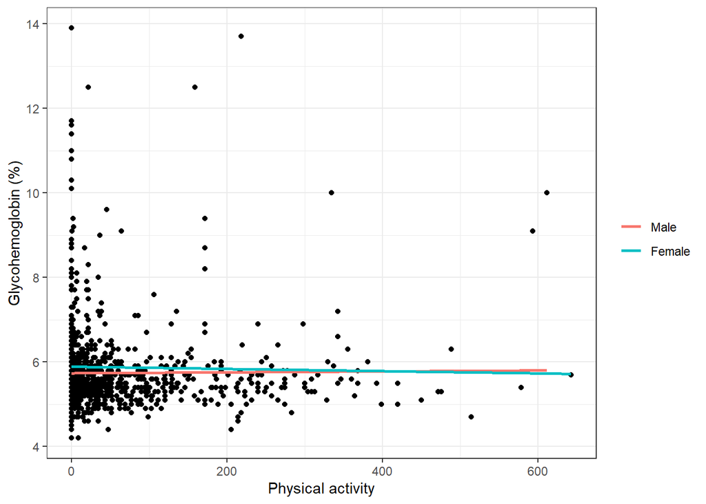

```r
ggplot() +
  geom_point(aes(x=`Physical activity`, y=`Glycohemoglobin (%)`), mutated_data_var_com) +
  geom_smooth(aes(x=`Physical activity`, y=`Glycohemoglobin (%)`, color = Sex), mutated_data_var_com,
              method = lm, , formula = y ~ x, se = FALSE) +
  labs(color = element_blank()) +
  theme_bw()
```

```r
contcont <- lm(`Glycohemoglobin (%)` ~ `Physical activity`*Age + Race + Sex + Smoking + asthma + `coronary heart disease`+ `congestive heart failure`+ `heart attack`+ `stroke`+`thyroid problem`+ COPD + malignancy + `high blood pressure`, mutated_data_var)
summary(contcont)
```

```
##
## Call:
## lm(formula = `Glycohemoglobin (%)` ~ `Physical activity` * Age +
##     Race + Sex + Smoking + asthma + `coronary heart disease` +
##     `congestive heart failure` + `heart attack` + stroke + `thyroid problem` +
##     COPD + malignancy + `high blood pressure`, data = mutated_data_var)
##
## Residuals:
##     Min      1Q  Median      3Q     Max
## -1.8919 -0.4435 -0.1577  0.1301  7.7703
##
## Coefficients:
##                                           Estimate Std. Error t value Pr(>|t|)
## (Intercept)                              6.695e+00  3.883e-01  17.243  < 2e-16
## `Physical activity`                      1.062e-03  1.153e-03   0.922   0.3569
## Age                                      1.318e-02  2.859e-03   4.611 4.59e-06
## RaceOther Hispanic                      -2.708e-01  1.503e-01  -1.801   0.0720
## RaceNon-Hispanic White                  -4.575e-01  1.091e-01  -4.193 3.03e-05
## RaceNon-Hispanic Black                  -2.485e-02  1.242e-01  -0.200   0.8415
## RaceNon-Hispanic Asian                  -1.089e-01  1.498e-01  -0.727   0.4673
## RaceOther Race - Including Multi-Racial -4.466e-01  2.254e-01  -1.982   0.0478
## SexFemale                                1.886e-02  7.458e-02   0.253   0.8004
## SmokingSome days                        -9.616e-02  1.960e-01  -0.491   0.6237
## SmokingNot at all                       -5.145e-02  9.558e-02  -0.538   0.5905
## asthmaNo                                -1.478e-02  9.104e-02  -0.162   0.8711
## `coronary heart disease`No              -4.720e-01  1.849e-01  -2.553   0.0108
## `congestive heart failure`No            -2.892e-01  1.979e-01  -1.461   0.1443
## `heart attack`No                        -2.203e-01  1.877e-01  -1.174   0.2408
## strokeNo                                -4.561e-01  1.795e-01  -2.540   0.0112
## `thyroid problem`No                      6.124e-02  1.006e-01   0.609   0.5428
## COPDNo                                   1.609e-01  1.739e-01   0.925   0.3550
## malignancyNo                            -9.040e-02  1.093e-01  -0.827   0.4084
## `high blood pressure`No                 -1.238e-01  7.258e-02  -1.706   0.0884
## `Physical activity`:Age                 -9.391e-06  2.342e-05  -0.401   0.6885
##
## (Intercept)                             ***
## `Physical activity`
## Age                                     ***
## RaceOther Hispanic                      .
## RaceNon-Hispanic White                  ***
## RaceNon-Hispanic Black
## RaceNon-Hispanic Asian
## RaceOther Race - Including Multi-Racial *
## SexFemale
## SmokingSome days
## SmokingNot at all
## asthmaNo
## `coronary heart disease`No              *
## `congestive heart failure`No
## `heart attack`No
## strokeNo                                *
## `thyroid problem`No
## COPDNo
## malignancyNo
## `high blood pressure`No                 .
## `Physical activity`:Age
## ---
## Signif. codes:  0 '***' 0.001 '**' 0.01 '*' 0.05 '.' 0.1 ' ' 1
##
## Residual standard error: 0.9765 on 892 degrees of freedom
## Multiple R-squared:  0.1321, Adjusted R-squared:  0.1127
## F-statistic:  6.79 on 20 and 892 DF,  p-value: < 2.2e-16
```